# [./Rohan Mahadev](https://rowhanm.github.io/)

### [Other posts](https://rowhanm.github.io/sections/research.html)

# Working with less data - Image classification with very few images

Every ML practitioner has attempted Kaggle's Dogs v/s Cats competition which pretty much is a solved problem thanks to methods like Transfer Learning on top of architectures like ResNet. But this dataset can be used to show some cool techniques by self imposing certain constraints, like using only a fraction of the data to obtain the same results!

This post is to illustrate how - with modern techniques - we can obtain near state-of-the-art results on image classification tasks. I'm going to use Kaggle's Dogs v/s Cats to prove my points, but these results can be extended to any similar task, including microscopic images, satellite images, and the works.

### The two techniques I'm going to experiment with are:

1. **Data augmentation.**
2. **Pseudo-labeling.** (a variant of semi-supervised learning)

I'm using Keras with a Tensorflow backend, but the same results can be obtained on any modern deep learning library thanks to great implementations of the above techniques being readily available.

Firstly, I import all necessary libraries:

```python
import numpy as np
import cv2
import os
import shutil
from glob import glob
import matplotlib.pyplot as plt
%matplotlib inline

from keras.preprocessing.image import ImageDataGenerator, array_to_img, img_to_array, load_img
from keras.models import *
from keras.layers import *
from keras.regularizers import *
from keras.optimizers import *

from IPython.display import Image
from keras import applications
```

I ran these experiments on an NVIDIA Titan X, so I could've afforded to use a higher batch size than 64 to speed things up.

```python
batch_size = 64
img_width, img_height = 200, 200
```

Now, I create the directory structure I need for training and validation

```python
%mkdir -p data/train/cats
%mkdir -p data/validate/cats
%mkdir -p data/train/dogs
%mkdir -p data/validate/dogs
```

This is the interesting bit, the original Dogs v/s Cats dataset has ~11,000 images for each category. So to prove my point that we can get good results with a very small amount of data, I select only the first 2000 images, i.e. 1000 per class.

```python
train_imgs = os.listdir('input/train')[:2000]
valid_imgs = os.listdir('input/train')[2000:2800]

for i in train_imgs:
    if i[:3] == 'cat':
        shutil.copy2('input/train/' + i, 'data/train/cats/')
    elif i[:3] == 'dog':
        shutil.copy2('input/train/' + i, 'data/train/dogs/')

for i in valid_imgs:
    if i[:3] == 'cat':
        shutil.copy2('input/train/' + i, 'data/validate/cats/')
    elif i[:3] == 'dog':
        shutil.copy2('input/train/' + i, 'data/validate/dogs/')
```

# Data augmentation

Augmenting data with a data generator with random affine transformations.

One of my favorite features in Keras is how smoothly it integrates with Python's generators and it's `flow_from_directory` method. This makes augmentation much simpler and avoids us storing all augmented images in disk.

```python
train_datagen = ImageDataGenerator(
    rescale=1./255,
    rotation_range=40,
    width_shift_range=0.2,
    height_shift_range=0.2,
    horizontal_flip=True,
    shear_range=0.1,)

train_generator = train_datagen.flow_from_directory(
        'data/train',
        target_size=(img_height,img_width),
        batch_size=batch_size,
        class_mode='binary')
```

```
Found 2000 images belonging to 2 classes.
```

I chose the above augmentation parameters by some trial and error. The best way to do this is to run the augmentation on a few samples and visualize the results. Our goal is to create images which still inherently preserve the characteristics of dogs or cats. Hence transformations like vertical flipping might not help.

So, the best thing to do is to plot these images, and keep tinkering with the values till you reach a satisfactory set.

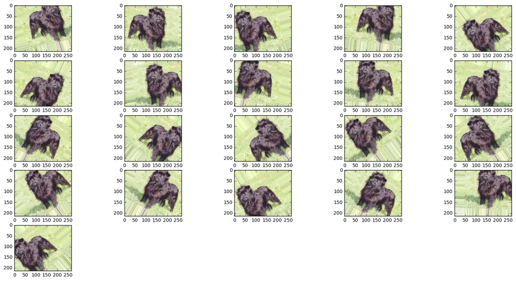

```python
images = os.listdir('preview')
plt.figure(figsize=(20,10))
columns = 5
for i, image in enumerate(images):
    plt.subplot(len(images) / columns + 1, columns, i + 1)
    image = load_img('preview/' + images[i])
    plt.imshow(image)
```

The validation set will only be rescaled to the size of the training set. But there are studies which show test time augmentation (TTA) or inference time augmentation - where you take the average of the results of a few augmented images on the test/validation set - give better results.

Here are some references - [Delving Deep into Rectifiers: Surpassing Human-Level Performance on ImageNet Classification by He, et al., 2015](https://arxiv.org/pdf/1502.01852.pdf) where the mention performing a "multi-view testing on feature maps".

```python
val_datagen = ImageDataGenerator(rescale=1./255)

val_generator = val_datagen.flow_from_directory(
        'data/validate',
        target_size=(img_height,img_width),
        batch_size=batch_size,
        class_mode='binary')
```

```
Found 800 images belonging to 2 classes.
```

```python
classes = len(train_generator.class_indices)
assert classes is len(val_generator.class_indices)
nb_train_samples = train_generator.samples
nb_val_samples = val_generator.samples
```

Here is another self-imposed constraint - I wont be using a pre-trained network and instead will use a conventional model with three convolution layers with some [Dropout](http://jmlr.org/papers/volume15/srivastava14a.old/srivastava14a.pdf) layers and [Batch Normalization.](https://arxiv.org/abs/1502.03167)

```python
model = Sequential([
    BatchNormalization(axis=1, input_shape=(img_width,img_height,3)),
    Convolution2D(32, (3,3), activation='relu'),
    BatchNormalization(axis=1),
    MaxPooling2D(),
    Convolution2D(64, (3,3), activation='relu'),
    BatchNormalization(axis=1),
    MaxPooling2D(),
    Convolution2D(128, (3,3), activation='relu'),
    BatchNormalization(axis=1),
    MaxPooling2D(),
    Flatten(),
    Dense(200, activation='relu'),
    BatchNormalization(),
    Dropout(0.5),
    Dense(200, activation='relu'),
    BatchNormalization(),
    Dropout(0.5),
    Dense(1, activation='sigmoid')
])
```

Now, I preform (quite a few) iterations of training and hyperparameter tuning.

```python
model.compile(Adam(lr=1e-4), loss='binary_crossentropy', metrics=['accuracy'])
model.summary()
```

```
_________________________________________________________________
Layer (type)                 Output Shape              Param #
=================================================================
batch_normalization_1 (Batch (None, 200, 200, 3)       800
_________________________________________________________________
conv2d_1 (Conv2D)            (None, 198, 198, 32)      896
_________________________________________________________________
batch_normalization_2 (Batch (None, 198, 198, 32)      792
_________________________________________________________________
max_pooling2d_1 (MaxPooling2 (None, 99, 99, 32)        0
_________________________________________________________________
conv2d_2 (Conv2D)            (None, 97, 97, 64)        18496
_________________________________________________________________
batch_normalization_3 (Batch (None, 97, 97, 64)        388
_________________________________________________________________
max_pooling2d_2 (MaxPooling2 (None, 48, 48, 64)        0
_________________________________________________________________
conv2d_3 (Conv2D)            (None, 46, 46, 128)       73856
_________________________________________________________________
batch_normalization_4 (Batch (None, 46, 46, 128)       184
_________________________________________________________________
max_pooling2d_3 (MaxPooling2 (None, 23, 23, 128)       0
_________________________________________________________________
flatten_1 (Flatten)          (None, 67712)             0
_________________________________________________________________
dense_1 (Dense)              (None, 200)               13542600
_________________________________________________________________
batch_normalization_5 (Batch (None, 200)               800
_________________________________________________________________
dropout_1 (Dropout)          (None, 200)               0
_________________________________________________________________
dense_2 (Dense)              (None, 200)               40200
_________________________________________________________________
batch_normalization_6 (Batch (None, 200)               800
_________________________________________________________________
dropout_2 (Dropout)          (None, 200)               0
_________________________________________________________________
dense_3 (Dense)              (None, 1)                 201
=================================================================
Total params: 13,680,013
Trainable params: 13,678,131
Non-trainable params: 1,882
_________________________________________________________________
```

```python
model.fit_generator(train_generator,
    steps_per_epoch=nb_train_samples//batch_size,
    epochs=15,
    validation_data=val_generator,
    validation_steps=nb_val_samples//batch_size)
```

```
<keras.callbacks.History at 0x7fb8f48ca3d0>
```

```python
model.fit_generator(train_generator,
    steps_per_epoch=nb_train_samples//batch_size,
    epochs=20,
    validation_data=val_generator,
    validation_steps=nb_val_samples//batch_size)
```

```
<keras.callbacks.History at 0x7fb850561e50>
```

```python
model.optimizer.lr=0.00005
model.fit_generator(train_generator,
    steps_per_epoch=nb_train_samples//batch_size,
    epochs=20,
    validation_data=val_generator,
    validation_steps=nb_val_samples//batch_size)
```

```
<keras.callbacks.History at 0x7fb850502b90>
```

I'm still at it...

```python
model.optimizer.lr=0.00001
model.fit_generator(train_generator,
    steps_per_epoch=nb_train_samples//batch_size,
    epochs=20,
    validation_data=val_generator,
    validation_steps=nb_val_samples//batch_size)
```

```
<keras.callbacks.History at 0x7fb8505dfd10>
```

```python
model.optimizer.lr=0.000004
model.fit_generator(train_generator,
    steps_per_epoch=nb_train_samples//batch_size,
    epochs=15,
    validation_data=val_generator,
    validation_steps=nb_val_samples//batch_size)
```

```
<keras.callbacks.History at 0x7fb850580c90>
```

#### Finally! I get to a validation loss of 0.45 which is not bad, but not too great either.

# Pseudo Labelling

#### Our model at this point is kinda good, we'll use this model to generate pseudo labels and and them to the training set and train again

```python
model.save_weights('data_aug.h5')
```

```python
test_datagen = ImageDataGenerator(rescale=1. / 255)
```

```python
test_batches = test_datagen.flow_from_directory('sample/', target_size=(img_height,img_width), shuffle=False, batch_size=1, class_mode=None)
```

```
Found 11 images belonging to 1 classes.
```

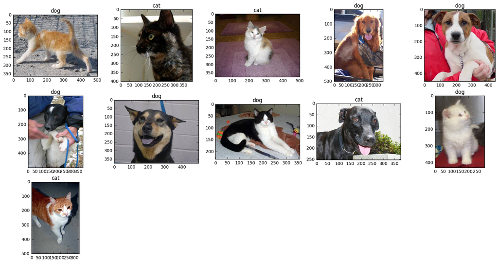

```python
images = os.listdir('sample/unknown')
predictions = model.predict_generator(test_batches)
predictions = predictions.reshape((11,))
plt.figure(figsize=(20,10))
columns = 5
for i, image in enumerate(images):
    plt.subplot(len(images) / columns + 1, columns, i + 1)
    image = load_img('sample/unknown/' + images[i])
    if predictions[i] > 0.5:
        plt.title('dog')
    else:
        plt.title('cat')
    plt.imshow(image)
```

```python
test_batches = test_datagen.flow_from_directory('pseudo_labelling/', target_size=(img_height,img_width), shuffle=False, batch_size=batch_size, class_mode=None)
predictions = model.predict_generator(test_batches)
predictions = predictions.reshape((predictions.shape[0],))
```

```
Found 791 images belonging to 1 classes.
```

```python
files = os.listdir('pseudo_labelling/unknown')
for i in range(len(files)):
    if predictions[i] > 0.5:
        os.rename('pseudo_labelling/unknown/' + files[i], 'data/train/dogs/' + files[i])
    else:
        os.rename('pseudo_labelling/unknown/' + files[i], 'data/train/cats/' + files[i])
```

```python
train_datagen = ImageDataGenerator(
    rescale=1./255,
    rotation_range=40,
    width_shift_range=0.2,
    height_shift_range=0.2,
    horizontal_flip=True,
    shear_range=0.1)

train_generator = train_datagen.flow_from_directory(
        'data/train',
        target_size=(img_height,img_width),
        batch_size=batch_size,
        class_mode='binary')

val_datagen = ImageDataGenerator(rescale=1./255)

val_generator = val_datagen.flow_from_directory(
        'data/validate',
        target_size=(img_height,img_width),
        batch_size=batch_size,
        class_mode='binary')

classes = len(train_generator.class_indices)
assert classes is len(val_generator.class_indices)
nb_train_samples = train_generator.samples
nb_val_samples = val_generator.samples

model.load_weights('data_aug.h5')
```

```
Found 2791 images belonging to 2 classes.
Found 800 images belonging to 2 classes.
```

```python
model.fit_generator(train_generator,
    steps_per_epoch=nb_train_samples//batch_size,
    epochs=15,
    validation_data=val_generator,
    validation_steps=nb_val_samples//batch_size)
```

```
<keras.callbacks.History at 0x7fb850311c50>
```

### After running several more iterations of hyper-parameter tuning, I got to a validation loss of 0.101 which would've gotten into the top 400 in the leaderboard.

### What can be observed from this experiment is that just by observing and tweaking our data a little and using some non-conventional methods, we aren't crippled by the inherent need of *tons of data to do deep learning*.

### Further things I'd like to try out with this are things like using GANs to generate images and augment the dataset. Try out other semi-supervised learning techniques like knowledge distillation, etc. which I hope to get around doing soon.